# Machine Learning II

BaselRBootcamp April 2018

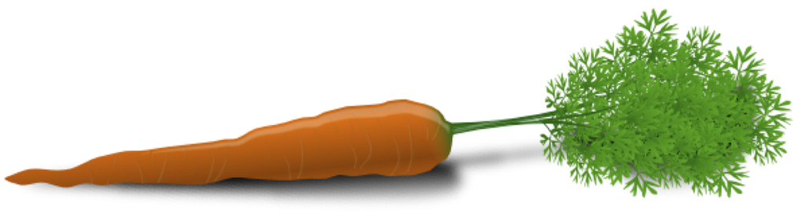

The almighty Caret!

### Slides

- [Here are the introduction slides for this practical on machine learning II!](https://therbootcamp.github.io/BaselRBootcamp_2018April/_sessions/D3S1_MachineLearningII/MachineLearningII.html)

### Overview

In this practical you’ll use the `caret` (**C**lassification **A**nd **RE**gression **T**raining) package to automate many aspects of the machine learning process. By the end of this practical you will know:

1. Select different ‘learners’ available in the `caret` package
2. Fit parameters of a learner to a dataset
3. Explore learners to understand how they work
4. Use cross validation techniques to estimate the accuracy of a learner and find best fitting parameters 5 Make predictions and evaluate the performance of learners!

### Datasets

You’ll use four datasets in this practical: `boston_train_csv` and `boston_test.csv`, `heartdisease_train.csv` and `heartdisease_test.csv`. They available in the `data_BaselRBootcamp_Day3.zip` file available through the main course page. If you haven’t already, download the `data_BaselRBootcamp_Day3.zip` folder and unzip it to get the files. We also recommend saving them in a folder called `data` in your working directory!

### Packages

For this practical, you will need the following packages. If you don’t have any installed, you’ll need to install them with `install.packages()`

```r
# Packages you'll need for this practical
library(caret)
library(mlr)
library(GGally)
library(mlbench)
library(tidyverse)
```

### Examples

The following set of example code will take you through the basic steps of machine learning using the amazing `caret` package.

```r
# Load packages
library(caret)
library(mlr)
library(GGally)
library(mlbench)
library(tidyverse)

# ---------------
# Setup
# ---------------

# Split diamonds data into separate training and test datasets
diamonds <- diamonds %>%
  sample_frac(1)                  # Randomly sort

# Create separate training and test data
diamonds_train <- diamonds %>%
  slice(1:500)

diamonds_test <- diamonds %>%
  slice(501:2000)

# ---------------
# Explore
# ---------------

# Explore columns with summarizeColumns
summarizeColumns(diamonds_train)

# Visualise relationships with ggpairs
ggpairs(diamonds_train)

# ---------------
# Train
# ---------------

# Set up control values
rep10_control <- trainControl(method = "repeatedcv",
                              number = 10, # 10 folds
                              repeats = 5) # Repeat 5 times

# Predict price with linear regression
diamonds_lm_train <- train(form = price ~ .,
                           data = diamonds_train,
                           method = "lm",
                           trControl = rep10_control)

# Explore the train object
class(diamonds_lm_train)
diamonds_lm_train
names(diamonds_lm_train)
summary(diamonds_lm_train)

# Look at variable importance with varImp
varImp(diamonds_lm_train)

# Save final predictions
diamonds_lm_predictions <- predict(diamonds_lm_train,
                                   newdata = diamonds_test)

# ---------------
# Evaluate
# ---------------

# Plot relationship between predictions and truth
performance_data <- tibble(predictions = diamonds_lm_predictions,
                          criterion = diamonds_test$price)

ggplot(data = performance_data,
       aes(x = predictions, y = criterion)) +
  geom_point() +   # Add points
  geom_abline(slope = 1, intercept = 0, col = "blue", size = 2) +
  labs(title = "Regression prediction accuracy",
       subtitle = "Blue line is perfect prediction!")

# Look at final prediction performance!
postResample(pred = diamonds_lm_predictions,
             obs = diamonds_test$price)
```

#### boston – predicting median home value (medv)

The `boston` dataset contains housing data for 506 census tracts of Boston from the 1970 census.

Here is a description of each of the variables in the dataset

| Column | Description |
| --- | --- |
| crim | per capita crime rate by town |
| zn | proportion of residential land zoned for lots over 25,000 sq.ft |
| indus | proportion of non-retail business acres per town |
| chas | Charles River dummy variable (= 1 if tract bounds river; 0 otherwise) |
| nox | nitric oxides concentration (parts per 10 million) |
| rm | average number of rooms per dwelling |
| age | proportion of owner-occupied units built prior to 1940 |
| dis | weighted distances to five Boston employment centres |
| rad | index of accessibility to radial highways |
| tax | full-value property-tax rate per USD 10,000 |
| ptratio | pupil-teacher ratio by town |
| b | 1000(B - 0.63)^2 where B is the proportion of blacks by town |
| lstat | percentage of lower status of the population |
| medv | median value of owner-occupied homes in USD 1000’s |

### (E)xplore

1. Load the training data `boston_train.csv` into R as a new object with the name `boston_train` using `read_csv()`.

```r
boston_train <- read_csv("data/boston_train.csv")
```

2. Explore the data using the standard functions `head()`, `View()`, `names()` and `summary()`

```r
head(boston_train)
```

```
# A tibble: 6 x 14
    crim    zn indus  chas   nox    rm   age   dis   rad   tax ptratio
   <dbl> <dbl> <dbl> <int> <dbl> <dbl> <dbl> <dbl> <int> <int>   <dbl>
1 3.54      0. 19.6      1 0.871  6.15  82.6  1.75     5   403    14.7
2 0.340     0. 21.9      0 0.624  6.46  98.9  2.12     4   437    21.2
3 0.0798   40.  6.41     0 0.447  6.48  32.1  4.14     4   254    17.6
4 0.773     0.  8.14     0 0.538  6.50  94.4  4.45     4   307    21.0
5 0.330     0.  6.20     0 0.507  6.09  61.5  3.65     8   307    17.4
6 0.103    30.  4.93     0 0.428  6.36  52.9  7.04     6   300    16.6
# ... with 3 more variables: b <dbl>, lstat <dbl>, medv <dbl>
```

3. Use the `summarizeColumns()` function from the `mlr` package to create numerical summaries of each column. Do you notice any strange columns?

```r
mlr::summarizeColumns(boston_train)
```

```
      name    type na       mean        disp     median         mad
1     crim numeric  0   4.017157  10.6362176   0.239745   0.3043481
2       zn numeric  0  12.835000  24.4253196   0.000000   0.0000000
3    indus numeric  0  11.644100   7.5021709   9.900000  11.4011940
4     chas integer  0   0.090000   0.2876235   0.000000   0.0000000
5      nox numeric  0   0.568709   0.1260641   0.544000   0.1319514
6       rm numeric  0   6.346150   0.7002630   6.278000   0.4885167
7      age numeric  0  70.893000  27.4259748  82.200000  24.2405100
8      dis numeric  0   3.493716   2.0120118   2.800100   1.4820070
9      rad integer  0   9.670000   8.8740400   5.000000   2.9652000
10     tax integer  0 415.710000 173.7767809 364.000000 139.3644000
11 ptratio numeric  0  18.289000   2.2834448  18.600000   2.3721600
12       b numeric  0 362.635300  84.7712980 390.720000   9.1624680
13   lstat numeric  0  12.349100   7.1234023  10.585000   6.1083120
14    medv numeric  0  23.326000   9.6243758  21.800000   5.9304000
         min      max nlevs
1    0.01096  73.5341     0
2    0.00000  95.0000     0
3    0.46000  27.7400     0
4    0.00000   1.0000     0
5    0.38900   0.8710     0
6    4.13800   8.3980     0
7    7.80000 100.0000     0
8    1.17420   9.2203     0
9    1.00000  24.0000     0
10 188.00000 711.0000     0
11  12.60000  21.2000     0
12  16.45000 396.9000     0
13   2.47000  34.7700     0
14   5.00000  50.0000     0
```

```r
# Nope they all look ok!
```

4. Can you think of a reason why you should remove any of the columns? If so, remove them using `select()`! There’s no need to include unnecessary data in a machine learning algorithm :)
5. Visualise the data using the `ggpairs()` function from the `GGally` package. Do you notice any interesting patterns?

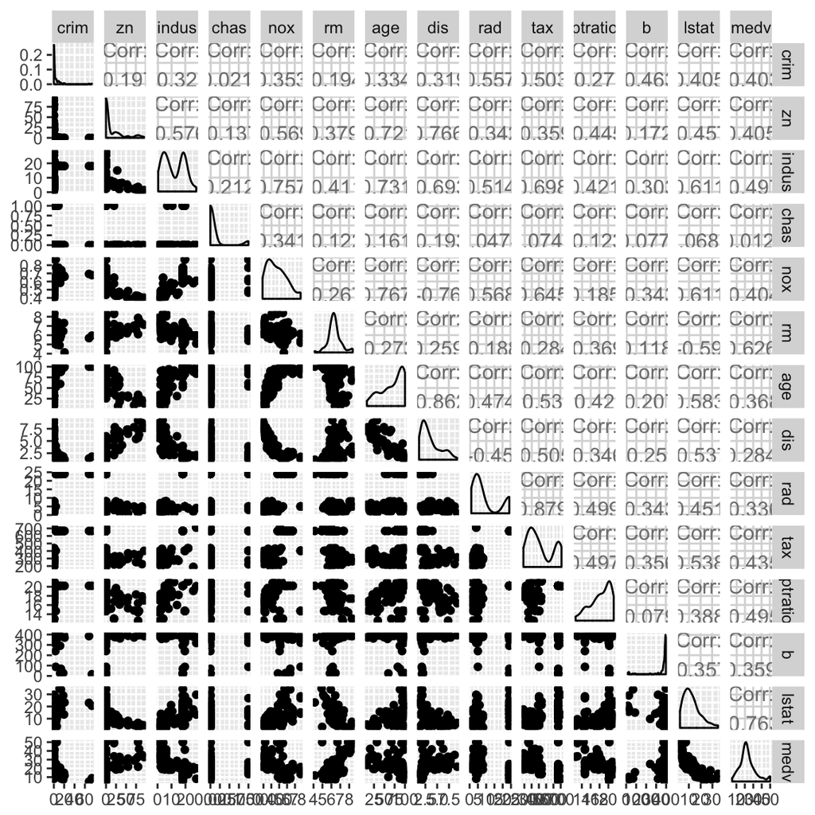

```r
ggpairs(boston_train)
```

### (T)rain

6. We will use 10-fold cross validation to train the models. To set up the fitting process, we’ll need to use the `trainControl` function. Look at the help menu for this function and look through the examples to see how it works.
7. Using the `trainControl()` function, create an object called `rep10_control` that will conduct 10-fold cross validation.

```r
rep10_control <- caret::trainControl(method = "repeatedcv",
                                    number = 10,
                                    search = "grid")          # Find optimal parameters
```

8. We’re almost ready to train models! To do so, we’ll use the almighty `train()` function. Look at the help menu for the `train()` function to see all of its lovely arguments and examples.

```r
?train
```

9. Now it’s time to actually train a model. We’ll start with simple linear regression. Create an object called `boston_lm_train` where you predict a town’s median home value `medv` based on all other variables. In order to conduct linear regression, include the arguments `method = 'lm'` and `trControl = rep10_control`

```r
boston_lm_train <- caret::train(form = medv ~ .,
                                        data = boston_train,
                                        method = "lm",
                                        trControl = rep10_control)
```

10. Explore your `boston_lm_train` argument using the generic functions `names()`, `summary()`, and `plot()`. What is stored in this object?

```r
boston_lm_train
```

```
Linear Regression

100 samples
 13 predictor

No pre-processing
Resampling: Cross-Validated (10 fold, repeated 1 times)
Summary of sample sizes: 90, 90, 91, 89, 90, 91, ...
Resampling results:

  RMSE      Rsquared  MAE
  5.896511  0.667127  4.522078

Tuning parameter 'intercept' was held constant at a value of TRUE
```

```r
summary(boston_lm_train)
```

```
Call:
lm(formula = .outcome ~ ., data = dat)

Residuals:
    Min      1Q  Median      3Q     Max
-10.548  -2.999  -0.452   2.584  18.646

Coefficients:
              Estimate Std. Error t value Pr(>|t|)
(Intercept)  53.236754  11.969055   4.448 2.58e-05 ***
crim         -0.150641   0.062897  -2.395 0.018790 *
zn            0.097746   0.036441   2.682 0.008767 **
indus        -0.064170   0.139644  -0.460 0.647019
chas          0.871467   1.984693   0.439 0.661694
nox         -18.843021   9.448875  -1.994 0.049297 *
rm            1.983625   1.006865   1.970 0.052045 .
age           0.039229   0.043431   0.903 0.368918
dis          -2.214633   0.579946  -3.819 0.000253 ***
rad           0.308793   0.139984   2.206 0.030056 *
tax          -0.004699   0.008022  -0.586 0.559580
ptratio      -1.254161   0.332930  -3.767 0.000302 ***
b             0.012235   0.007149   1.712 0.090587 .
lstat        -0.756288   0.118553  -6.379 8.61e-09 ***
---
Signif. codes:  0 '***' 0.001 '**' 0.01 '*' 0.05 '.' 0.1 ' ' 1

Residual standard error: 5.017 on 86 degrees of freedom
Multiple R-squared:  0.764, Adjusted R-squared:  0.7283
F-statistic: 21.41 on 13 and 86 DF,  p-value: < 2.2e-16
```

11. Using the `varImp()` function, look at the variable importance of each predictor. Which predictors seem to be the most important? After you’ve run the function, try plotting the object with `plot()` to visualise the results!

```r
caret::varImp(boston_lm_train)
```

```
lm variable importance

         Overall
lstat   100.0000
dis      56.8933
ptratio  56.0239
zn       37.7630
crim     32.9271
rad      29.7434
nox      26.1794
rm       25.7735
b        21.4207
age       7.8137
tax       2.4688
indus     0.3439
chas      0.0000
```

12. Load the test dataset as a new object called `boston_test` into R using `read_csv()`

```r
boston_test <- read_csv("data/boston_test.csv")
```

13. Now it’s time to make predictions form your model! Using `predict()`, predict the criterion values for the test dataset `boston_test`. In the `object` argument, use your `boston_lm_train` model, in the `newdata` argument, use your `boston_test` test data. Save the results as the vector `boston_lm_predictions`

```r
boston_lm_predictions <- predict(boston_lm_train,
                                 newdata = boston_test)
```

### (E)valuate model performance

14. How well did your model do in predicting the true data? To start, plot the relationship between your model predictions and the true criterion using the following template

```r
# Combine predictions and criterion in one tibble
performance_data <- tibble(predictions = boston_lm_predictions,
                          criterion = boston_test$medv)

# Plot results
ggplot(data = performance_data,
       aes(x = predictions, y = criterion)) +
  geom_point() +   # Add points
  geom_abline(slope = 1, intercept = 0, col = "blue", size = 2) +
  labs(title = "Regression prediction accuracy",
       subtitle = "Blue line is perfect prediction!")
```

[output not shown]

15. Now it’s time to quantify how well your model did. To do this, we’ll evaluate its performance with `postResample()`. Start by looking at the help menu for the `postResample()` function to see its arguments.

```r
?postResample
```

16. Now evaluate the model’s predictions using `postResample()`. You should only specify the `pred` and `obs` arguments as `pred = boston_lm_predictions` and `obs = boston_test$medv`.

```r
postResample(pred = boston_lm_predictions,
             obs = boston_test$medv)
```

```
     RMSE  Rsquared       MAE
5.1690046 0.6859913 3.8336613
```

17. How well did your model do? What was the overall level of accuracy? If you don’t understand the results, look at the details in the help menu for help!